# **Régression Logistique sur un Dataset Réel**

## **Introduction**

Dans ce volet, il s'agira de confronter les versions "maison" de nos algorithmes de descente de gradient et de prédiction à un jeu de données du réel. Ce jeu de données est un dataset issu d'une banque portugaise, dont l'objectif est d'identifier les clients les plus enclins à souscrire un produit financier. En plus d'être plus volumineux qu'un dataset académique, un jeu de données issu du terrain peut challenger la descente de gradient de par sa plus grande variabilité et son bruit, surtout en présence d'un déséquilibre entre les classes.

Une première partie consistera à reproduire les mêmes traitements et choix que la démonstration, afin d'aboutir à un dataset ajusté et exploitatble par nos algorithmes.

Dans la deuxième partie, la régression logistique sera appliquée avec les méthodes d'optimisation implémentées dans le Bloc-1, auxquelles ont été rajoutées deux implémentations de descente de gradient pénalisées, La ridge et la Lasso.

## **I- Reproduction des traitements et choix de variables dans le dataset**

Cette partie se contente d'acquérir le dataset et de lui appliquer les mêmes traitements que dans la démonstration.

```python
import pandas as pd
import numpy as np
from sklearn import preprocessing
import matplotlib.pyplot as plt
plt.rc("font", size=14)
from sklearn.linear_model import LogisticRegression
from sklearn.model_selection import train_test_split
import seaborn as sns
sns.set(style="white")
sns.set(style="whitegrid", color_codes=True)
import statsmodels.api as sm
from IPython.display import display
from sklearn.metrics import roc_curve, auc


from Optimisations import * # fichier Optimisations.py: Nos descentes de gradients élaborés en bloc-1 + DG pénalisée Ridge + DG pénalisée Lasso
from Outils import * # fichier Outils.py: les fonctions de prédiction, des outils de plot..
```

#### **DATA**

```python
data = pd.read_csv('bank.csv', header=0)
data = data.dropna()
print(data.shape)
print(list(data.columns))
```

```
(41188, 21)
['age', 'job', 'marital', 'education', 'default', 'housing', 'loan', 'contact', 'month', 'day_of_week', 'duration', 'campaign', 'pdays', 'previous', 'poutcome', 'emp_var_rate', 'cons_price_idx', 'cons_conf_idx', 'euribor3m', 'nr_employed', 'y']
```

```python
data.dtypes
```

```
age                 int64
job                object
marital            object
education          object
default            object
housing            object
loan               object
contact            object
month              object
day_of_week        object
duration            int64
campaign            int64
pdays               int64
previous            int64
poutcome           object
emp_var_rate      float64
cons_price_idx    float64
cons_conf_idx     float64
euribor3m         float64
nr_employed       float64
y                   int64
dtype: object
```

```python
data.head()
```

|  | age | job | marital | education | default | housing | loan | contact | month | day_of_week | ... | campaign | pdays | previous | poutcome | emp_var_rate | cons_price_idx | cons_conf_idx | euribor3m | nr_employed | y |
| --- | --- | --- | --- | --- | --- | --- | --- | --- | --- | --- | --- | --- | --- | --- | --- | --- | --- | --- | --- | --- | --- |
| 0 | 44 | blue-collar | married | basic.4y | unknown | yes | no | cellular | aug | thu | ... | 1 | 999 | 0 | nonexistent | 1.4 | 93.444 | -36.1 | 4.963 | 5228.1 | 0 |
| 1 | 53 | technician | married | unknown | no | no | no | cellular | nov | fri | ... | 1 | 999 | 0 | nonexistent | -0.1 | 93.200 | -42.0 | 4.021 | 5195.8 | 0 |
| 2 | 28 | management | single | university.degree | no | yes | no | cellular | jun | thu | ... | 3 | 6 | 2 | success | -1.7 | 94.055 | -39.8 | 0.729 | 4991.6 | 1 |
| 3 | 39 | services | married | high.school | no | no | no | cellular | apr | fri | ... | 2 | 999 | 0 | nonexistent | -1.8 | 93.075 | -47.1 | 1.405 | 5099.1 | 0 |
| 4 | 55 | retired | married | basic.4y | no | yes | no | cellular | aug | fri | ... | 1 | 3 | 1 | success | -2.9 | 92.201 | -31.4 | 0.869 | 5076.2 | 1 |

5 rows × 21 columns

#### **Grouping Columns**

```python
data['education'].unique()
```

```
array(['basic.4y', 'unknown', 'university.degree', 'high.school',
       'basic.9y', 'professional.course', 'basic.6y', 'illiterate'],
      dtype=object)
```

```python
data['education']=np.where(data['education'] =='basic.9y', 'Basic', data['education'])
data['education']=np.where(data['education'] =='basic.6y', 'Basic', data['education'])
data['education']=np.where(data['education'] =='basic.4y', 'Basic', data['education'])
```

```python
data['education'].unique()
```

```
array(['Basic', 'unknown', 'university.degree', 'high.school',
       'professional.course', 'illiterate'], dtype=object)
```

#### **Exploration**

```python
data['y'].value_counts()
```

```
y
0    36548
1     4640
Name: count, dtype: int64
```

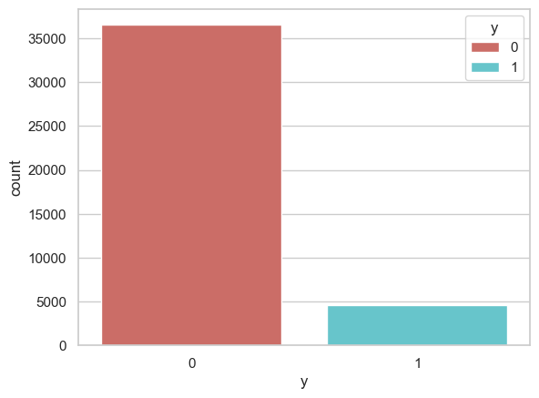

```python
sns.countplot(x='y', data=data, palette='hls', hue='y')
plt.show()
plt.savefig('count plot')
```

```python
count_no_sub = len(data[data['y']==0])
count_sub = len(data[data['y']==1])
pct_of_no_sub = count_no_sub/(count_no_sub+count_sub)
print("percentage of no subscription is", pct_of_no_sub*100)
pct_of_sub = count_sub/(count_no_sub+count_sub)
print("percentage of subscription", pct_of_sub*100)
```

```
percentage of no subscription is 88.73458288821988
percentage of subscription 11.265417111780131
```

```python
data.groupby('y').mean(numeric_only=True)
```

| y | age | duration | campaign | pdays | previous | emp_var_rate | cons_price_idx | cons_conf_idx | euribor3m | nr_employed |
| --- | --- | --- | --- | --- | --- | --- | --- | --- | --- | --- |
| 0 | 39.911185 | 220.844807 | 2.633085 | 984.113878 | 0.132374 | 0.248875 | 93.603757 | -40.593097 | 3.811491 | 5176.166600 |
| 1 | 40.913147 | 553.191164 | 2.051724 | 792.035560 | 0.492672 | -1.233448 | 93.354386 | -39.789784 | 2.123135 | 5095.115991 |

```python
data.groupby('job').mean(numeric_only=True)
```

| job | age | duration | campaign | pdays | previous | emp_var_rate | cons_price_idx | cons_conf_idx | euribor3m | nr_employed | y |
| --- | --- | --- | --- | --- | --- | --- | --- | --- | --- | --- | --- |
| admin. | 38.187296 | 254.312128 | 2.623489 | 954.319229 | 0.189023 | 0.015563 | 93.534054 | -40.245433 | 3.550274 | 5164.125350 | 0.129726 |
| blue-collar | 39.555760 | 264.542360 | 2.558461 | 985.160363 | 0.122542 | 0.248995 | 93.656656 | -41.375816 | 3.771996 | 5175.615150 | 0.068943 |
| entrepreneur | 41.723214 | 263.267857 | 2.535714 | 981.267170 | 0.138736 | 0.158723 | 93.605372 | -41.283654 | 3.791120 | 5176.313530 | 0.085165 |
| housemaid | 45.500000 | 250.454717 | 2.639623 | 960.579245 | 0.137736 | 0.433396 | 93.676576 | -39.495283 | 4.009645 | 5179.529623 | 0.100000 |
| management | 42.362859 | 257.058140 | 2.476060 | 962.647059 | 0.185021 | -0.012688 | 93.522755 | -40.489466 | 3.611316 | 5166.650513 | 0.112175 |
| retired | 62.027326 | 273.712209 | 2.476744 | 897.936047 | 0.327326 | -0.698314 | 93.430786 | -38.573081 | 2.770066 | 5122.262151 | 0.252326 |
| self-employed | 39.949331 | 264.142153 | 2.660802 | 976.621393 | 0.143561 | 0.094159 | 93.559982 | -40.488107 | 3.689376 | 5170.674384 | 0.104856 |
| services | 37.926430 | 258.398085 | 2.587805 | 979.974049 | 0.154951 | 0.175359 | 93.634659 | -41.290048 | 3.699187 | 5171.600126 | 0.081381 |
| student | 25.894857 | 283.683429 | 2.104000 | 840.217143 | 0.524571 | -1.408000 | 93.331613 | -40.187543 | 1.884224 | 5085.939086 | 0.314286 |
| technician | 38.507638 | 250.232241 | 2.577339 | 964.408127 | 0.153789 | 0.274566 | 93.561471 | -39.927569 | 3.820401 | 5175.648391 | 0.108260 |
| unemployed | 39.733728 | 249.451677 | 2.564103 | 935.316568 | 0.199211 | -0.111736 | 93.563781 | -40.007594 | 3.466583 | 5157.156509 | 0.142012 |
| unknown | 45.563636 | 239.675758 | 2.648485 | 938.727273 | 0.154545 | 0.357879 | 93.718942 | -38.797879 | 3.949033 | 5172.931818 | 0.112121 |

```python
data.groupby('marital').mean(numeric_only=True)
```

| marital | age | duration | campaign | pdays | previous | emp_var_rate | cons_price_idx | cons_conf_idx | euribor3m | nr_employed | y |
| --- | --- | --- | --- | --- | --- | --- | --- | --- | --- | --- | --- |
| divorced | 44.899393 | 253.790330 | 2.61340 | 968.639853 | 0.168690 | 0.163985 | 93.606563 | -40.707069 | 3.715603 | 5170.878643 | 0.103209 |
| married | 42.307165 | 257.438623 | 2.57281 | 967.247673 | 0.155608 | 0.183625 | 93.597367 | -40.270659 | 3.745832 | 5171.848772 | 0.101573 |
| single | 33.158714 | 261.524378 | 2.53380 | 949.909578 | 0.211359 | -0.167989 | 93.517300 | -40.918698 | 3.317447 | 5155.199265 | 0.140041 |
| unknown | 40.275000 | 312.725000 | 3.18750 | 937.100000 | 0.275000 | -0.221250 | 93.471250 | -40.820000 | 3.313038 | 5157.393750 | 0.150000 |

```python
data.groupby('education').mean(numeric_only=True)
```

| education | age | duration | campaign | pdays | previous | emp_var_rate | cons_price_idx | cons_conf_idx | euribor3m | nr_employed | y |
| --- | --- | --- | --- | --- | --- | --- | --- | --- | --- | --- | --- |
| Basic | 42.163910 | 263.043874 | 2.559498 | 974.877967 | 0.141053 | 0.191329 | 93.639933 | -40.927595 | 3.729654 | 5172.014113 | 0.087029 |
| high.school | 37.998213 | 260.886810 | 2.568576 | 964.358382 | 0.185917 | 0.032937 | 93.584857 | -40.940641 | 3.556157 | 5164.994735 | 0.108355 |
| illiterate | 48.500000 | 276.777778 | 2.277778 | 943.833333 | 0.111111 | -0.133333 | 93.317333 | -39.950000 | 3.516556 | 5171.777778 | 0.222222 |
| professional.course | 40.080107 | 252.533855 | 2.586115 | 960.765974 | 0.163075 | 0.173012 | 93.569864 | -40.124108 | 3.710457 | 5170.155979 | 0.113485 |
| university.degree | 38.879191 | 253.223373 | 2.563527 | 951.807692 | 0.192390 | -0.028090 | 93.493466 | -39.975805 | 3.529663 | 5163.226298 | 0.137245 |
| unknown | 43.481225 | 262.390526 | 2.596187 | 942.830734 | 0.226459 | 0.059099 | 93.658615 | -39.877816 | 3.571098 | 5159.549509 | 0.145003 |

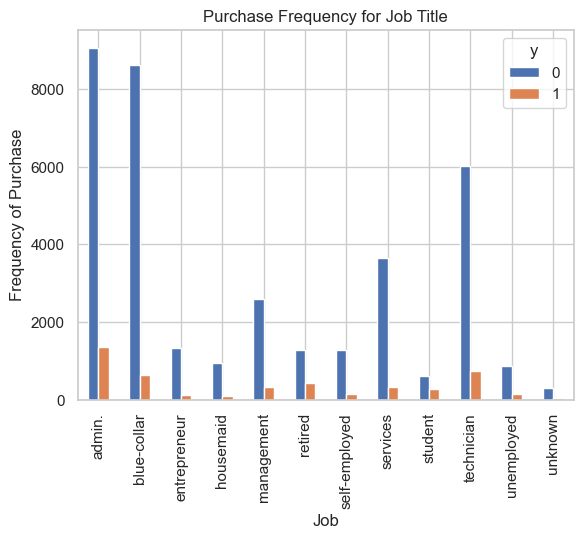

```python
%matplotlib inline
pd.crosstab(data.job,data.y).plot(kind='bar')
plt.title('Purchase Frequency for Job Title')
plt.xlabel('Job')
plt.ylabel('Frequency of Purchase')
plt.savefig('purchase_fre_job')
```

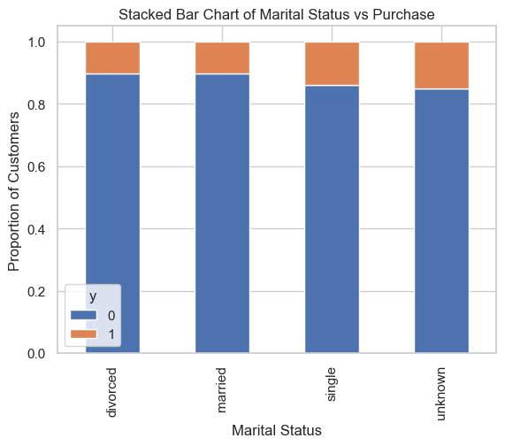

```python
table=pd.crosstab(data.marital,data.y)
table.div(table.sum(1).astype(float), axis=0).plot(kind='bar', stacked=True)
plt.title('Stacked Bar Chart of Marital Status vs Purchase')
plt.xlabel('Marital Status')
plt.ylabel('Proportion of Customers')
plt.savefig('mariral_vs_pur_stack')
```

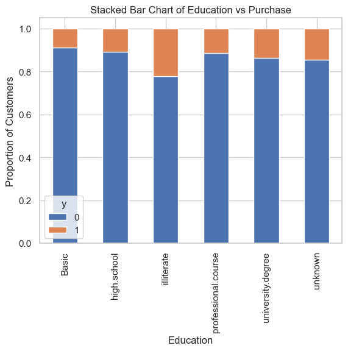

```python
table=pd.crosstab(data.education,data.y)
table.div(table.sum(1).astype(float), axis=0).plot(kind='bar', stacked=True)
plt.title('Stacked Bar Chart of Education vs Purchase')
plt.xlabel('Education')
plt.ylabel('Proportion of Customers')
plt.savefig('edu_vs_pur_stack')
```

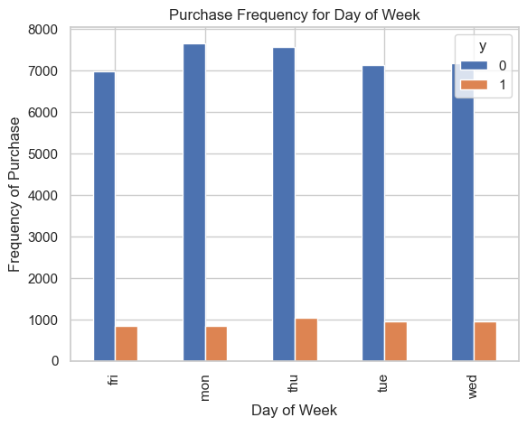

```python
pd.crosstab(data.day_of_week,data.y).plot(kind='bar')
plt.title('Purchase Frequency for Day of Week')
plt.xlabel('Day of Week')
plt.ylabel('Frequency of Purchase')
plt.savefig('pur_dayofweek_bar')
```

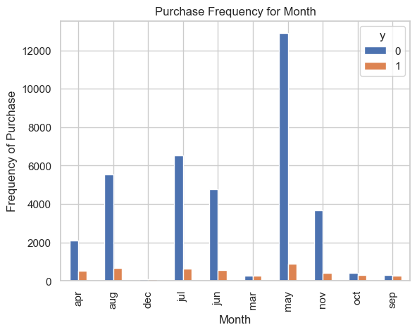

```python
pd.crosstab(data.month,data.y).plot(kind='bar')
plt.title('Purchase Frequency for Month')
plt.xlabel('Month')
plt.ylabel('Frequency of Purchase')
plt.savefig('pur_fre_month_bar')
```

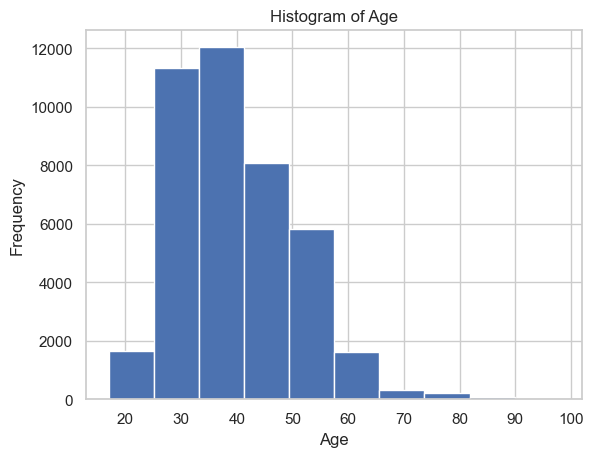

```python
data.age.hist()
plt.title('Histogram of Age')
plt.xlabel('Age')
plt.ylabel('Frequency')
plt.savefig('hist_age')
```

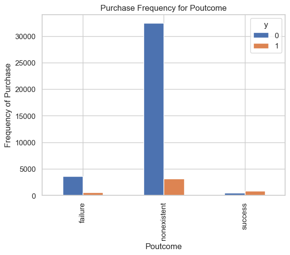

```python
pd.crosstab(data.poutcome,data.y).plot(kind='bar')
plt.title('Purchase Frequency for Poutcome')
plt.xlabel('Poutcome')
plt.ylabel('Frequency of Purchase')
plt.savefig('pur_fre_pout_bar')
```

#### **Transformation Dummy variables**

```python
cat_vars=['job','marital','education','default','housing','loan','contact','month','day_of_week','poutcome']
for var in cat_vars:
    cat_list='var'+'_'+var
    cat_list = pd.get_dummies(data[var], prefix=var)
    cat_list = cat_list.astype(int)
    data1=data.join(cat_list)
    data=data1
cat_vars=['job','marital','education','default','housing','loan','contact','month','day_of_week','poutcome']
data_vars=data.columns.values.tolist()
to_keep=[i for i in data_vars if i not in cat_vars]
```

```python
# Trouver toutes les colonnes de type booléen et les convertir en int
data[data.select_dtypes(['bool']).columns] = data.select_dtypes(['bool']).astype(int)

data.dtypes[:50]
```

```
age                                int64
job                               object
marital                           object
education                         object
default                           object
housing                           object
loan                              object
contact                           object
month                             object
day_of_week                       object
duration                           int64
campaign                           int64
pdays                              int64
previous                           int64
poutcome                          object
emp_var_rate                     float64
cons_price_idx                   float64
cons_conf_idx                    float64
euribor3m                        float64
nr_employed                      float64
y                                  int64
job_admin.                         int32
job_blue-collar                    int32
job_entrepreneur                   int32
job_housemaid                      int32
job_management                     int32
job_retired                        int32
job_self-employed                  int32
job_services                       int32
job_student                        int32
job_technician                     int32
job_unemployed                     int32
job_unknown                        int32
marital_divorced                   int32
marital_married                    int32
marital_single                     int32
marital_unknown                    int32
education_Basic                    int32
education_high.school              int32
education_illiterate               int32
education_professional.course      int32
education_university.degree        int32
education_unknown                  int32
default_no                         int32
default_unknown                    int32
default_yes                        int32
housing_no                         int32
housing_unknown                    int32
housing_yes                        int32
loan_no                            int32
dtype: object
```

```python
data_final=data[to_keep]
data_final.columns.values
```

```
array(['age', 'duration', 'campaign', 'pdays', 'previous', 'emp_var_rate',
       'cons_price_idx', 'cons_conf_idx', 'euribor3m', 'nr_employed', 'y',
       'job_admin.', 'job_blue-collar', 'job_entrepreneur',
       'job_housemaid', 'job_management', 'job_retired',
       'job_self-employed', 'job_services', 'job_student',
       'job_technician', 'job_unemployed', 'job_unknown',
       'marital_divorced', 'marital_married', 'marital_single',
       'marital_unknown', 'education_Basic', 'education_high.school',
       'education_illiterate', 'education_professional.course',
       'education_university.degree', 'education_unknown', 'default_no',
       'default_unknown', 'default_yes', 'housing_no', 'housing_unknown',
       'housing_yes', 'loan_no', 'loan_unknown', 'loan_yes',
       'contact_cellular', 'contact_telephone', 'month_apr', 'month_aug',
       'month_dec', 'month_jul', 'month_jun', 'month_mar', 'month_may',
       'month_nov', 'month_oct', 'month_sep', 'day_of_week_fri',
       'day_of_week_mon', 'day_of_week_thu', 'day_of_week_tue',
       'day_of_week_wed', 'poutcome_failure', 'poutcome_nonexistent',
       'poutcome_success'], dtype=object)
```

#### **Oversampling using SMOTE**

```python
X = data_final.loc[:, data_final.columns != 'y']
y = data_final.loc[:, data_final.columns == 'y']
from imblearn.over_sampling import SMOTE
os = SMOTE(random_state=0)
X_train, X_test, y_train, y_test = train_test_split(X, y, test_size=0.3, random_state=0)
columns = X_train.columns
os_data_X,os_data_y=os.fit_resample(X_train, y_train)
os_data_X = pd.DataFrame(data=os_data_X,columns=columns )
os_data_y= pd.DataFrame(data=os_data_y,columns=['y'])
# we can Check the numbers of our data
print("length of oversampled data is ",len(os_data_X))
print("Number of no subscription in oversampled data",len(os_data_y[os_data_y['y']==0]))
print("Number of subscription",len(os_data_y[os_data_y['y']==1]))
print("Proportion of no subscription data in oversampled data is ",len(os_data_y[os_data_y['y']==0])/len(os_data_X))
print("Proportion of subscription data in oversampled data is ",len(os_data_y[os_data_y['y']==1])/len(os_data_X))
```

```
length of oversampled data is  51134
Number of no subscription in oversampled data 25567
Number of subscription 25567
Proportion of no subscription data in oversampled data is  0.5
Proportion of subscription data in oversampled data is  0.5
```

#### **Elimination des features les moins pertinentes**

```python
cols=['euribor3m', 'job_blue-collar', 'job_housemaid', 'marital_unknown', 'education_illiterate',
      'month_apr', 'month_aug', 'month_dec', 'month_jul', 'month_jun', 'month_mar',
      'month_may', 'month_nov', 'month_oct', "poutcome_failure", "poutcome_success"]
X=os_data_X[cols]
y=os_data_y['y']
logit_model=sm.Logit(y,X)
result=logit_model.fit()
print(result.summary2())
```

```
Optimization terminated successfully.
         Current function value: 0.547516
         Iterations 7
                           Results: Logit
=====================================================================
Model:                Logit             Method:            MLE
Dependent Variable:   y                 Pseudo R-squared:  0.210
Date:                 2024-09-29 01:42  AIC:               56025.3929
No. Observations:     51134             BIC:               56166.8681
Df Model:             15                Log-Likelihood:    -27997.
Df Residuals:         51118             LL-Null:           -35443.
Converged:            1.0000            LLR p-value:       0.0000
No. Iterations:       7.0000            Scale:             1.0000
---------------------------------------------------------------------
                      Coef.  Std.Err.    z     P>|z|   [0.025  0.975]
---------------------------------------------------------------------
euribor3m             0.1726   0.0055  31.1231 0.0000  0.1617  0.1835
job_blue-collar      -1.0761   0.0360 -29.9182 0.0000 -1.1465 -1.0056
job_housemaid        -1.6936   0.1293 -13.1030 0.0000 -1.9469 -1.4403
marital_unknown      -1.1130   0.4136  -2.6908 0.0071 -1.9237 -0.3023
education_illiterate  0.1325   0.6595   0.2009 0.8408 -1.1602  1.4251
month_apr            -0.2660   0.0414  -6.4323 0.0000 -0.3470 -0.1849
month_aug            -1.6700   0.0393 -42.4900 0.0000 -1.7471 -1.5930
month_dec            -0.1384   0.1606  -0.8616 0.3889 -0.4532  0.1764
month_jul            -1.6077   0.0391 -41.1482 0.0000 -1.6843 -1.5311
month_jun            -1.3552   0.0394 -34.4030 0.0000 -1.4324 -1.2779
month_mar             0.7367   0.0859   8.5771 0.0000  0.5684  0.9050
month_may            -1.5298   0.0302 -50.7233 0.0000 -1.5889 -1.4707
month_nov            -1.7487   0.0467 -37.4200 0.0000 -1.8403 -1.6571
month_oct             0.4962   0.0751   6.6078 0.0000  0.3490  0.6434
poutcome_failure      0.0003   0.0419   0.0063 0.9950 -0.0818  0.0824
poutcome_success      3.1910   0.0595  53.6365 0.0000  3.0744  3.3076
=====================================================================
```

#### **Modèle de l'exemple**

```python
from sklearn.linear_model import LogisticRegression
from sklearn import metrics
X_train, X_test, y_train, y_test = train_test_split(X, y, test_size=0.3, random_state=0)
from sklearn.linear_model import LogisticRegression

logreg = LogisticRegression(
    C=1.0,
    class_weight=None,
    dual=False,
    fit_intercept=True,
    intercept_scaling=1,
    max_iter=100,
    multi_class='ovr',
    n_jobs=1,
    penalty='l2',
    random_state=None,
    solver='liblinear',
    tol=0.0001,
    verbose=0,
    warm_start=False
)

logreg.fit(X_train, y_train)
```

```
LogisticRegression(multi_class='ovr', n_jobs=1, solver='liblinear')
```

```python
y_pred = logreg.predict(X_test)
print('Accuracy of logistic regression classifier on test set: {:.2f}'.format(logreg.score(X_test, y_test)))
```

```
Accuracy of logistic regression classifier on test set: 0.84
```

## **II- Régressions et résultats**

Appliquons nos algorithmes de descente à ce dataset:

```python
# paramètres
n_features = X_train.shape[1]
w_random = random_initialize_parameters(n_features)
learning_rate = 0.5
num_iterations = 1000
batch_size = 256
momentum = 0.9
epsilon = 1e-8
lambda_reg = 0.1  # Pour Ridge et Lasso


# N'oublions pas que nos algorithmes fonctionnent avec des matrics et que nous avons des dataframes:
X_train = X_train.to_numpy()
y_train = y_train.to_numpy()

X_test = X_test.to_numpy()
y_test = y_test.to_numpy()
```

```python
# descente de gradient simple:
w_gd, costs_gd = gradient_descent(X_train, y_train, w_random, learning_rate, num_iterations)
```

```python
# descente de gradient stochastique :
w_sgd, costs_sgd = stochastic_gradient_descent(X_train, y_train, w_random, learning_rate, num_epochs=8, batch_size=256)
```

```python
# descente de gradient avec momentum
w_momentum, costs_momentum = gradient_descent_momentum(X_train, y_train, w_random, learning_rate, num_iterations=1000)
```

```python
# descente de gradient Nesterov
w_nesterov, costs_nesterov = gradient_descent_nesterov(X_train, y_train, w_random, learning_rate, num_iterations)
```

```python
# descente de gradient adagrad
w_adagrad, costs_adagrad = gradient_descent_adagrad(X_train, y_train, w_random, learning_rate, num_iterations)
```

```python
# descente de gradient RMSprop
w_rmsprop, costs_rmsprop = gradient_descent_rmsprop(X_train, y_train, w_random, learning_rate, num_iterations)
```

```python
# descente de gradient Adam
w_adam, costs_adam = gradient_descent_adam(X_train, y_train, w_random, learning_rate, num_iterations)
```

```python
# descente de gradient avec régularisation ridge
w_ridge, costs_ridge = gradient_descent_ridge(X_train, y_train, w_random, learning_rate, num_iterations, lambda_reg)
```

```python
# descente de gradient avec régularisation Lasso
w_lasso, costs_lasso = gradient_descent_lasso(X_train, y_train, w_random, learning_rate, num_iterations, lambda_reg)
```

```python
# regroupons en dictionnaire nos résultats
results_costs = {
    'Gradient Descent': costs_gd,
    'SGD': costs_sgd,
    'Momentum': costs_momentum,
    'Nesterov': costs_nesterov,
    'AdaGrad': costs_adagrad,
    'RMSProp': costs_rmsprop,
    'Adam': costs_adam,
    'Ridge': costs_ridge,
    'Lasso': costs_lasso
}

results_weights = {
    'Gradient Descent': w_gd,
    'SGD': w_sgd,
    'Momentum': w_momentum,
    'Nesterov': w_nesterov,
    'AdaGrad': w_adagrad,
    'RMSProp': w_rmsprop,
    'Adam': w_adam,
    'Ridge': w_ridge,
    'Lasso': w_lasso
}
```

#### **1- Courbes de convergence de la perte:**

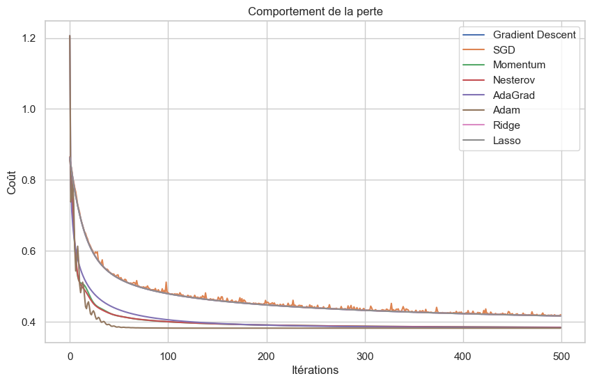

```python
exclure = ["RMSProp"]
plot_losses(results_costs, index_min=0, index_max=500, dontplot=exclure)
```

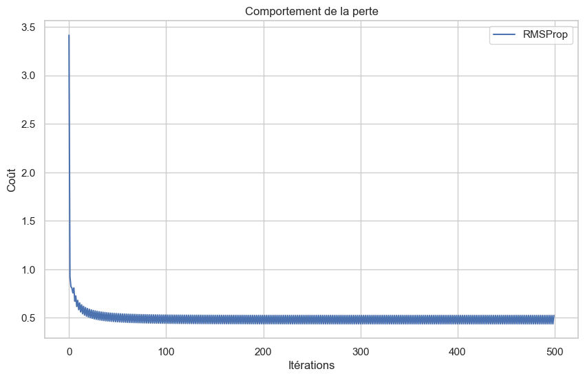

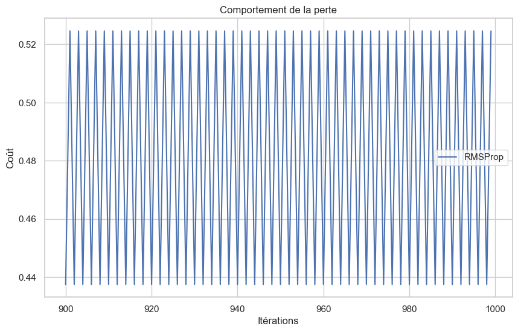

```python
inclure = ["RMSProp"]
plot_losses(results_costs, index_min=0, index_max=500, plot=inclure)
plot_losses(results_costs, index_min=900, index_max=1000, plot=inclure)
```

#### **2- Prédictions avec les poids optimaux obtenus par chaque méthode:**

Essayons d'utiliser nos poids maintenant, afin de prédire les labels sur le set de test

```python
# Dictionnaire pour stocker les prédictions des labels pour chaque algorithme
results_labels = {}

# Seuil de 0.5
threshold = 0.5

# Appliquer la prédiction pour chaque algorithme dans results_weights
for algo, weights in results_weights.items():
    # Calculer les probabilités avec sigmoid
    probabilities = predict(X_test, weights)

    # Appliquer le seuil de 0.5 pour obtenir les prédictions en 0 ou 1
    labels = (probabilities >= threshold).astype(int)

    # Stocker les labels dans le dictionnaire results_labels
    results_labels[algo] = labels

# Affichage des résultats de l'accuracy (nombre de bonnes réponses sur tout le dataset de test)
for algo, labels in results_labels.items():
    accuracy = np.mean(y_test == labels)
    print(f"Accuracy de l'algorithme {algo}: {accuracy:.4f}")
```

```
Accuracy de l'algorithme Gradient Descent: 0.8400
Accuracy de l'algorithme SGD: 0.8288
Accuracy de l'algorithme Momentum: 0.8355
Accuracy de l'algorithme Nesterov: 0.8355
Accuracy de l'algorithme AdaGrad: 0.8381
Accuracy de l'algorithme RMSProp: 0.8082
Accuracy de l'algorithme Adam: 0.8361
Accuracy de l'algorithme Ridge: 0.8400
Accuracy de l'algorithme Lasso: 0.8400
```

#### **2- Calcul des différentes métriques pour chaque algorithme**

Pour éviter la saturation en code dans le notebook, les fonctions "maison" de calcul des différentes métriques ainsi que les fonctions d'affichage sont dans le fichier **Outils.py**. Voici le tableau récapitulatif des différentes métriques pour chaque type de descente de gradient:

```python
# Calcul des métriques (accuracy, precision, recall et F1-score) pour toutes les descentes
all_algos_metrics = calculate_all_metrics_for_all(y_test, results_labels)
# Affichage
display_metrics_dataframe(all_algos_metrics)
```

|  | Algorithme | Accuracy | Precision | Recall | F1 Score |
| --- | --- | --- | --- | --- | --- |
| 0 | Gradient Descent | 0.840037 | 0.888294 | 0.778111 | 0.829560 |
| 1 | SGD | 0.828825 | 0.833620 | 0.821889 | 0.827713 |
| 2 | Momentum | 0.835474 | 0.885958 | 0.770293 | 0.824087 |
| 3 | Nesterov | 0.835474 | 0.885958 | 0.770293 | 0.824087 |
| 4 | AdaGrad | 0.838146 | 0.892145 | 0.769511 | 0.826303 |
| 5 | RMSProp | 0.808226 | 0.944246 | 0.655375 | 0.773727 |
| 6 | Adam | 0.836060 | 0.881318 | 0.776938 | 0.825843 |
| 7 | Ridge | 0.840037 | 0.888294 | 0.778111 | 0.829560 |
| 8 | Lasso | 0.840037 | 0.888294 | 0.778111 | 0.829560 |

Nos algorithmes montrent de bons résultats sur les différentes métriques, en particulier:

Pour avoir une idée plus claire, voici leurs matrices de confusion:

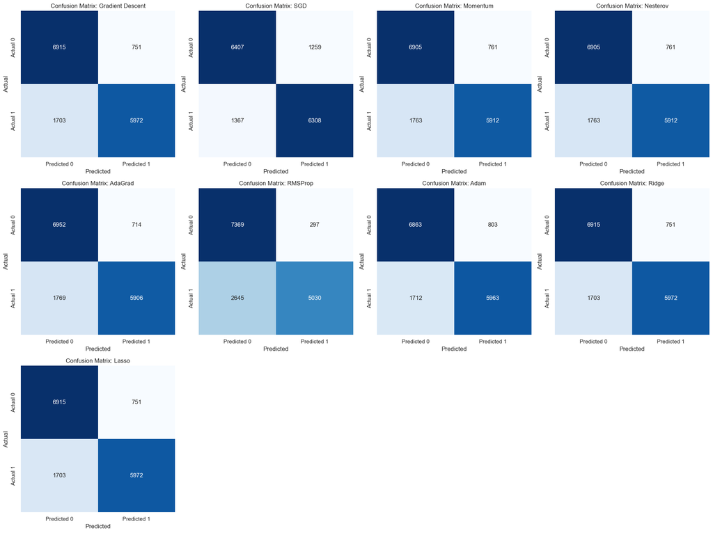

```python
plot_confusion_matrices(all_algos_metrics)
```

Ces résultats sont à interpréter à la lumière de l'objectif. Ici, il est d'identifier de potentiels clients d'un produit financier :

- Faux positifs: on prédit qu'un client est intéressé (ou potentiel) alors qu'il ne l'est pas réellement.

Impact : l'entreprise dépense des ressources (temps, argent, efforts marketing) sur des clients qui ne sont finalement pas intéressés. Cela peut représenter un coût financier mais n'a pas d'impact direct sur les opportunités de revenu.

- Faux négatifs: on prédit qu'un client n'est pas intéressé, alors qu'il l'est.

Impact : l'entreprise manque une opportunité de convertir un client potentiel, ce qui peut entraîner une perte de revenu. En plus, rater un client revient à renforcer la concurrence qui la capte (effet double).

L'erreur à minimiser dans ce contexte est l'erreur de type 2, c'est à dire les faux négatifs. Dans un contexte commercial, cette erreur est souvent plus coûteuse car l'acquisition de nouveaux clients est généralement une priorité.

la descente de gradient stochastique montre de très bons résultats pour le recall, tout en gardant un bon compromis f1-score. Elle serait apriori la plus adaptée pour cette problématique.

Visualisons sa courbe ROC-AUC :

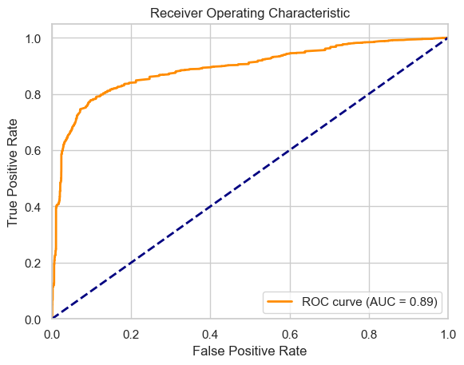

```
AUC pour la descente de gradient stochastique: 0.89
```

```python
# calculer et afficher la courbe ROC-AUC
probabilities_sgd = predict(X_test, w_sgd)
auc_sgd = plot_roc_curve(y_test, probabilities_sgd)
print(f"AUC pour la descente de gradient stochastique: {auc_sgd:.2f}")
```

L'aire sous la courbe est de 0,89, ce qui signifie que la probabilité qu'un échantillon positif ait un score prédictif supérieur à celui d'un échantillon négatif, est de 89 % :

$\text{AUC} = P(\text{Score}_{\text{positif}} > \text{Score}_{\text{négatif}}) = 0{,}89$

où :

- $P$ représente ici la probabilité.
- $\text{Score}_{\text{positif}}$ est le score ou la probabilité attribué par le modèle à un échantillon positif.
- $\text{Score}_{\text{négatif}}$ est le score ou la probabilité attribué à un échantillon négatif.

Ce qui représente une performance très acceptable du modèle de descente de gradient stochastique dans cet exercice.

## **Conclusion**

Cette partie expérimentale sur un dataset réel de marketing bancaire a permis de mettre en pratique et comparer différentes méthodes d'optimisation qu'on a implémenté pour la régression logistique :

Ce taux élevé de bonnes prédictions est à relativiser certainement par le fait que ça reste un dataset de benchmarking, et qu'il exite probablement des spécificités aux variables choisis qui demanderaient plus de recherches.

En tous cas, Ces résultats démontrent l'efficacité des méthodes implémentées et leur capacité à solutionner ce problème complexe qui est l'optimisation d'une fonction de perte.

Dans ce travail, le focus a été mis sur une fonction de perte "Convexe", sur laquelle les algorithmes d'optimisation, en particulier de descente de gradient restent globalement efficaces et prévisisbles. Cependant, la réalité des problèmes complexes d'apprentissage automatique dépasse souvent ce cadre simple et bien défini. De nombreux modèles performants, tels que les réseaux de neurones profonds, reposent sur des fonctions de perte non convexes, où les défis d'optimisation deviennent nettement plus complexes.